# ProGeny: The Children of Stars

Aaron Robotham

2024-10-22

Load what we will need:

```r
library(ProGeny)
library(ProSpect)
library(data.table)
library(Rfits)
library(fst)
library(magicaxis)
```

The main thing **ProGeny** does (and the reason it was designed at all) is to create Simple Stellar Population (SSP) models that can directly load into **ProSpect**. This is useful because it gives us full control over what isochrones and stellar atmospheres we use, and how we map them together. We can also control our initial mass function (IMF).

The basic path to doing this is to firstly load our desired isochrones (MIST, in this case). On my machine this is at:

```r
MistIso  = read.fst('~/Dropbox (Personal)/ProGeny_isochrone/MistIso.fst', as.data.table=TRUE)
#ParsecIso  = read.fst('~/Dropbox (Personal)/ProGeny_isochrone/ParsecIso.fst')
#BastiIso  = read.fst('~/Dropbox (Personal)/ProGeny_isochrone/BastiIso_New.fst')
```

If you do not have one already, you can get them using the *progenyIsoDownload* function. Currently we provide MIST (preferred, for reasons we shall get to), PARSEC and BaSTI as base isochrones.

Here we load four different base spectra options: C3K, PHOENIX (Husser) MILES and BaSeL (msotly styled as BASEL below). To get these locally you will need to run *progenyAtmosDownload*. The below might take about a minute to run (depending on the speed of your HDD or SSD).

```r
Spec_C3K = progenyAtmosLoad('~/Dropbox (Personal)/ProGeny_atmos/', base='combine_C3K_conroy')
Spec_PHOENIX = progenyAtmosLoad('~/Dropbox (Personal)/ProGeny_atmos/', base='combine_PHOENIX_husser')
Spec_MILES = progenyAtmosLoad('~/Dropbox (Personal)/ProGeny_atmos/', base='combine_MILES_vazdekis')
Spec_BASEL = progenyAtmosLoad('~/Dropbox (Personal)/ProGeny_atmos/', base='combine_BASEL_wlbc')
```

Below we interpolate our spectra onto the isochrone grid of Teff, logG and logZ. The below might take a minute or two to run (depending on your CPU speed). For this example we will use MIST, but keen users should try switching to alternative isochrones.

```r
Interp_PHOENIX = progenyInterpGrid_All(Iso = MistIso, Spec_combine = Spec_PHOENIX)
Interp_C3K = progenyInterpGrid_All(Iso = MistIso, Spec_combine = Spec_C3K)
Interp_MILES = progenyInterpGrid_All(Iso = MistIso, Spec_combine = Spec_MILES)
Interp_BASEL = progenyInterpGrid_All(Iso = MistIso, Spec_combine = Spec_BASEL)
```

We need to update the isochrones with the origin of the ‘best’ spectra (since we can only have one per isochrone element). The below should be very fast. Make sure you pass back in the appropriate isochrone (MIST in this case). Note also you will need to change the arguments for label_AGB and label_white if switching isochrones (since different isochrones use different labelling systems, as suggested by the comments).

```r
Iso_C3K = progenyInterpBest(Iso = MistIso,
                        Interp_combine = Interp_C3K,
                        label_AGB = 4:5, #7:8 [PC] / 4:5 [Mist]
                        label_white = 6:8 # 9 [PC] / 6:8 [Mist]
                        )

Iso_PHOENIX = progenyInterpBest(Iso = MistIso,
                        Interp_combine = Interp_PHOENIX,
                        label_AGB = 4:5, #7:8 [PC] / 4:5 [Mist]
                        label_white = 6:8 # 9 [PC] / 6:8 [Mist]
                        )

Iso_MILES = progenyInterpBest(Iso = MistIso,
                        Interp_combine = Interp_MILES,
                        label_AGB = 4:5, #7:8 [PC] / 4:5 [Mist]
                        label_white = 6:8 # 9 [PC] / 6:8 [Mist]
                        )

Iso_BASEL = progenyInterpBest(Iso = MistIso,
                        Interp_combine = Interp_BASEL,
                        label_AGB = 4:5, #7:8 [PC] / 4:5 [Mist]
                        label_white = 6:8 # 9 [PC] / 6:8 [Mist]
                        )
```

And finally we can put these steps together to generate our SSPs with our desired target IMF (Chabrier in this case). The below will take a good few minutes to run (depending on your CPU speed and number of cores).

```r
PG_Ch_C3K = progenyMakeSSP(Iso = Iso_C3K,
                               IMFfunc = IMF_Chabrier,
                               masslow = 0.1,
                               massmax = 100,
                               Spec_combine = Spec_C3K,
                               Interp_combine = Interp_C3K
               )
```

```
## Generating spec grids:
```

```
## Generating evo grids:
```

```r
PG_Ch_PHOENIX = progenyMakeSSP(Iso = Iso_PHOENIX,
                               IMFfunc = IMF_Chabrier, #but perhaps try IMF_Kroupa or IMF_kroupa
                               masslow = 0.1,
                               massmax = 100,
                               Spec_combine = Spec_PHOENIX,
                               Interp_combine = Interp_PHOENIX
               )
```

```
## Generating spec grids:
## Generating evo grids:
```

```r
PG_Ch_MILES = progenyMakeSSP(Iso = Iso_MILES,
                               IMFfunc = IMF_Chabrier,
                               masslow = 0.1,
                               massmax = 100,
                               Spec_combine = Spec_MILES,
                               Interp_combine = Interp_MILES
               )
```

```
## Generating spec grids:
## Generating evo grids:
```

```r
PG_Ch_BASEL = progenyMakeSSP(Iso = Iso_BASEL,
                               IMFfunc = IMF_Chabrier,
                               masslow = 0.1,
                               massmax = 100,
                               Spec_combine = Spec_BASEL,
                               Interp_combine = Interp_BASEL
               )
```

```
## Generating spec grids:
## Generating evo grids:
```

We can check this with our **ProSpect** *speclib_check* function:

```r
speclib_check(PG_Ch_C3K) #just checking this one since it our fiducial SSP
```

```
## Skeleton checks:
```

```
##  speclib list check passed
```

```
##  speclib list names check passed
```

```
## General sub-list checks:
```

```
##  - Z vector check passed
```

```
##  - Z numeric check passed
```

```
##  - Age vector check passed
```

```
##  - Age numeric check passed
```

```
##  - AgeBins vector check passed
```

```
##  - AgeBins numeric check passed
```

```
##  - AgeWeights vector check passed
```

```
##  - AgeWeights numeric check passed
```

```
##  - AgeWeights consistent with AgeBins check passed
```

```
##  - Wave vector check passed
```

```
##  - Wave numeric check passed
```

```
##  - Labels list check passed
```

```
##  - Zspec list check passed
```

```
##  - Zevo list check passed
```

```
## Detailed checks:
```

```
##  - - Zspec[[1]] matrix check passed
```

```
##  - - Zspec[[2]] matrix check passed
```

```
##  - - Zspec[[3]] matrix check passed
```

```
##  - - Zspec[[4]] matrix check passed
```

```
##  - - Zspec[[5]] matrix check passed
```

```
##  - - Zspec[[6]] matrix check passed
```

```
##  - - Zspec[[7]] matrix check passed
```

```
##  - - Zspec[[8]] matrix check passed
```

```
##  - - Zspec[[9]] matrix check passed
```

```
##  - - Zspec[[10]] matrix check passed
```

```
##  - - Zspec[[11]] matrix check passed
```

```
##  - - Zspec[[12]] matrix check passed
```

```
##  - - Zspec[[13]] matrix check passed
```

```
##  - - Zspec[[14]] matrix check passed
```

```
##  - - Zspec[[15]] matrix check passed
```

```
##  - - Zspec[[1]] +ve flux check passed
```

```
##  - - Zspec[[2]] +ve flux check passed
```

```
##  - - Zspec[[3]] +ve flux check passed
```

```
##  - - Zspec[[4]] +ve flux check passed
```

```
##  - - Zspec[[5]] +ve flux check passed
```

```
##  - - Zspec[[6]] +ve flux check passed
```

```
##  - - Zspec[[7]] +ve flux check passed
```

```
##  - - Zspec[[8]] +ve flux check passed
```

```
##  - - Zspec[[9]] +ve flux check passed
```

```
##  - - Zspec[[10]] +ve flux check passed
```

```
##  - - Zspec[[11]] +ve flux check passed
```

```
##  - - Zspec[[12]] +ve flux check passed
```

```
##  - - Zspec[[13]] +ve flux check passed
```

```
##  - - Zspec[[14]] +ve flux check passed
```

```
##  - - Zspec[[15]] +ve flux check passed
```

```
##  - - Zevo[[1]] data.frame check passed
```

```
##  - - Zevo[[1]] colnames check passed
```

```
##  - - Zevo[[1]]$SMstar numeric check passed
```

```
##  - - Zevo[[2]] data.frame check passed
```

```
##  - - Zevo[[2]] colnames check passed
```

```
##  - - Zevo[[2]]$SMstar numeric check passed
```

```
##  - - Zevo[[3]] data.frame check passed
```

```
##  - - Zevo[[3]] colnames check passed
```

```
##  - - Zevo[[3]]$SMstar numeric check passed
```

```
##  - - Zevo[[4]] data.frame check passed
```

```
##  - - Zevo[[4]] colnames check passed
```

```
##  - - Zevo[[4]]$SMstar numeric check passed
```

```
##  - - Zevo[[5]] data.frame check passed
```

```
##  - - Zevo[[5]] colnames check passed
```

```
##  - - Zevo[[5]]$SMstar numeric check passed
```

```
##  - - Zevo[[6]] data.frame check passed
```

```
##  - - Zevo[[6]] colnames check passed
```

```
##  - - Zevo[[6]]$SMstar numeric check passed
```

```
##  - - Zevo[[7]] data.frame check passed
```

```
##  - - Zevo[[7]] colnames check passed
```

```
##  - - Zevo[[7]]$SMstar numeric check passed
```

```
##  - - Zevo[[8]] data.frame check passed
```

```
##  - - Zevo[[8]] colnames check passed
```

```
##  - - Zevo[[8]]$SMstar numeric check passed
```

```
##  - - Zevo[[9]] data.frame check passed
```

```
##  - - Zevo[[9]] colnames check passed
```

```
##  - - Zevo[[9]]$SMstar numeric check passed
```

```
##  - - Zevo[[10]] data.frame check passed
```

```
##  - - Zevo[[10]] colnames check passed
```

```
##  - - Zevo[[10]]$SMstar numeric check passed
```

```
##  - - Zevo[[11]] data.frame check passed
```

```
##  - - Zevo[[11]] colnames check passed
```

```
##  - - Zevo[[11]]$SMstar numeric check passed
```

```
##  - - Zevo[[12]] data.frame check passed
```

```
##  - - Zevo[[12]] colnames check passed
```

```
##  - - Zevo[[12]]$SMstar numeric check passed
```

```
##  - - Zevo[[13]] data.frame check passed
```

```
##  - - Zevo[[13]] colnames check passed
```

```
##  - - Zevo[[13]]$SMstar numeric check passed
```

```
##  - - Zevo[[14]] data.frame check passed
```

```
##  - - Zevo[[14]] colnames check passed
```

```
##  - - Zevo[[14]]$SMstar numeric check passed
```

```
##  - - Zevo[[15]] data.frame check passed
```

```
##  - - Zevo[[15]] colnames check passed
```

```
##  - - Zevo[[15]]$SMstar numeric check passed
```

```
##  - - Labels string check passed
```

```
##  - - Labels list names check passed
```

```
## Congratulations - all speclib checks are passing!
```

```
## Z min / med / max: 2e-06 0.0011246826503807 0.0632455532033676 [15]
```

```
## Age min / med / max: 1e+05 44668359.2150963 19952623149.6888 [107]
```

```
## Wave min / med / max: 5.59999990463257 5507.44995117188 3.6e+08 [16902]
```

```
## Wave Bin min / med / max: 0.3994140625 0.5 1.2e+08
```

Hopefully it all passes! I won’t do this for all of the SSPs here though (too much clutter).

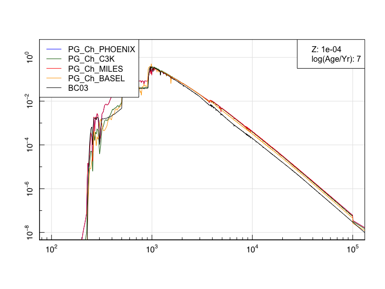

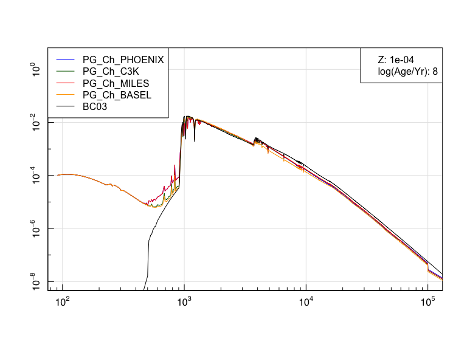

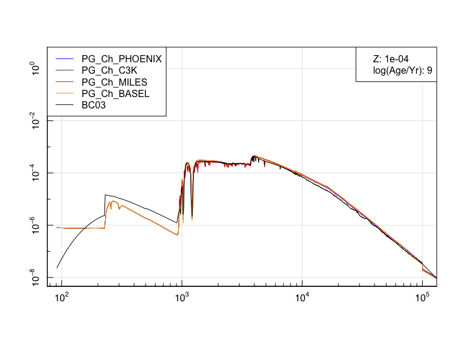

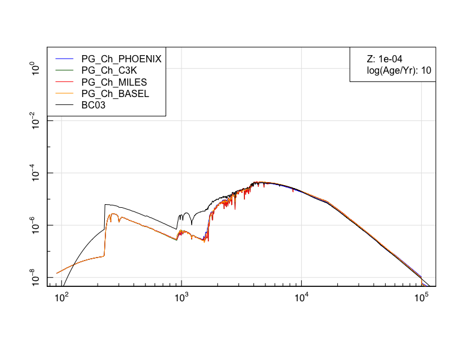

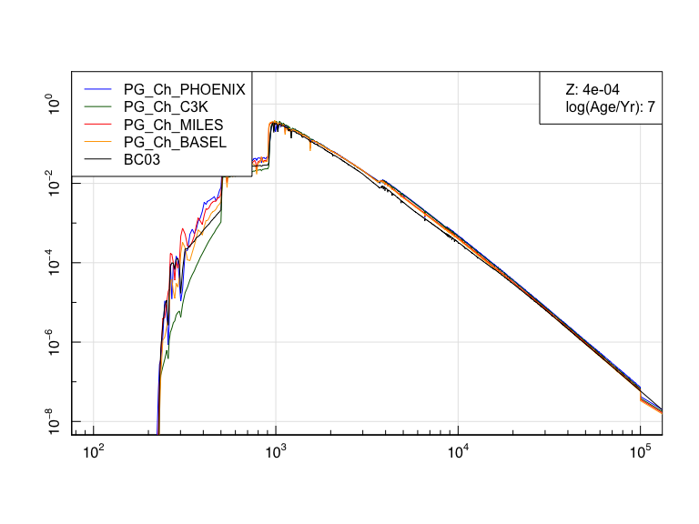

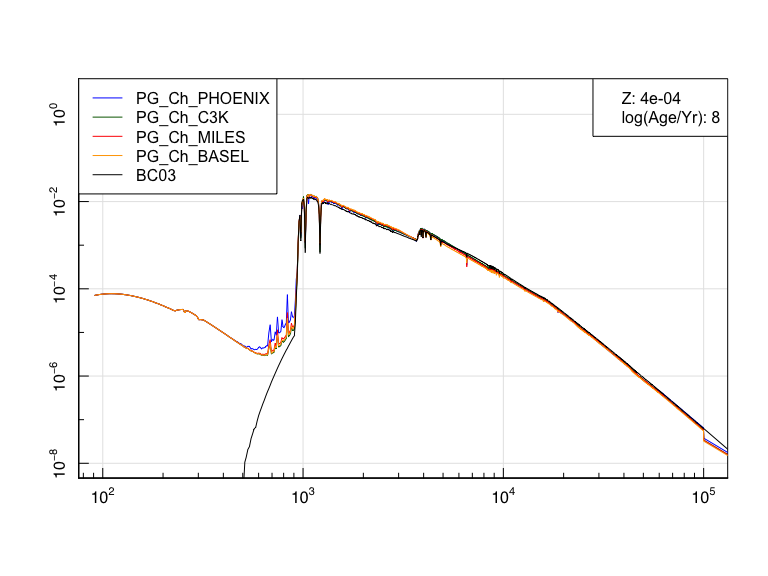

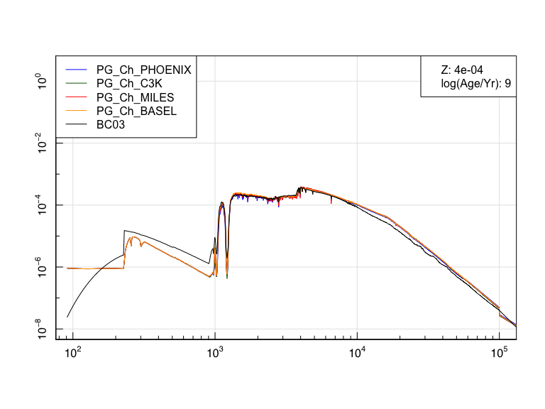

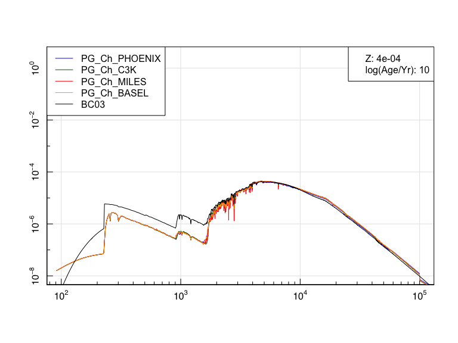

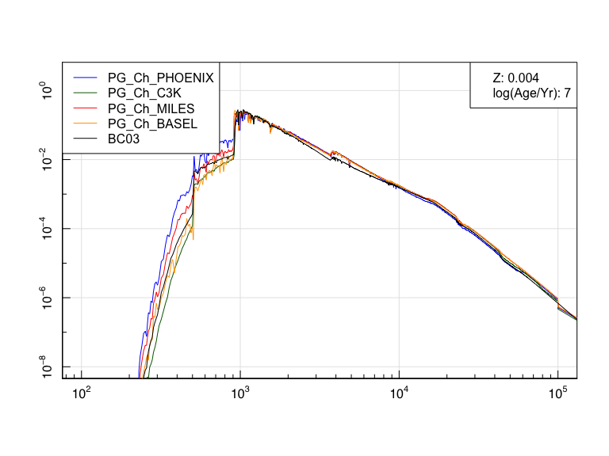

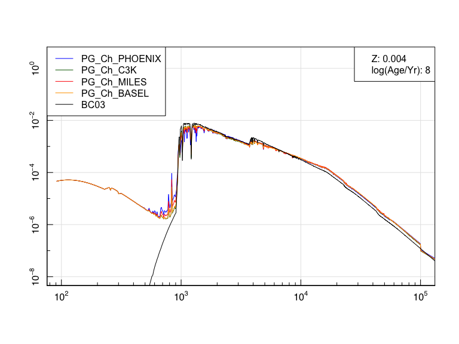

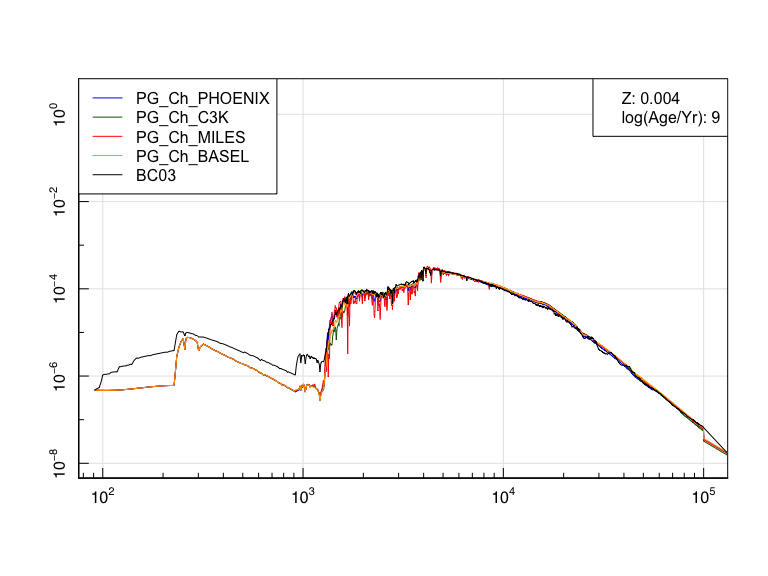

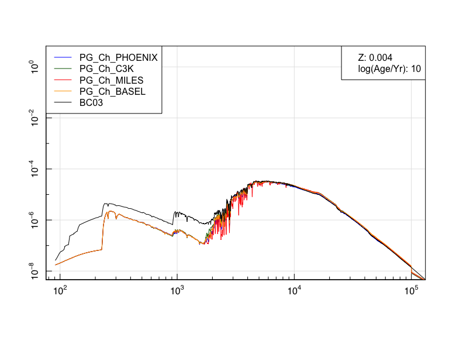

[12 more figures not shown]

```r
data(BC03lr)

for(Z in BC03lr$Z){
  for(logAge in 7:10){
    temp_PHOENIX = specReBin(PG_Ch_PHOENIX$Wave, PG_Ch_PHOENIX$Zspec[[min(which(PG_Ch_PHOENIX$Z >= Z))]][min(which(PG_Ch_PHOENIX$Age >= 10^logAge)),], BC03lr$Wave)
    temp_C3K = specReBin(PG_Ch_C3K$Wave, PG_Ch_C3K$Zspec[[min(which(PG_Ch_C3K$Z >= Z))]][min(which(PG_Ch_C3K$Age >= 10^logAge)),], BC03lr$Wave)
    temp_MILES = specReBin(PG_Ch_MILES$Wave, PG_Ch_MILES$Zspec[[min(which(PG_Ch_MILES$Z >= Z))]][min(which(PG_Ch_MILES$Age >= 10^logAge)),], BC03lr$Wave)
    temp_BASEL = specReBin(PG_Ch_BASEL$Wave, PG_Ch_BASEL$Zspec[[min(which(PG_Ch_BASEL$Z >= Z))]][min(which(PG_Ch_BASEL$Age >= 10^logAge)),], BC03lr$Wave)

    magplot(NA, NA, log='xy', xlim=c(1e2,1e5), ylim=c(1e-8,3))
    lines(temp_PHOENIX, col='blue')
    lines(temp_C3K, col='darkgreen')
    lines(temp_MILES, col='red')
    lines(temp_BASEL, col='orange')
    lines(BC03lr$Wave, BC03lr$Zspec[[min(which(BC03lr$Z >= Z))]][min(which(BC03lr$Age >= 10^logAge)),], col='black')
    legend('topleft', legend=c('PG_Ch_PHOENIX', 'PG_Ch_C3K', 'PG_Ch_MILES', 'PG_Ch_BASEL', 'BC03'), col=c('blue', 'darkgreen', 'red', 'orange', 'black'), lty=1)
    legend('topright', legend=c(paste('Z:',Z), paste('log(Age/Yr):',logAge)))
  }
}
```

It is also interesting to compare the stellar evolutionary tracks, in particular the mass remaining in stars with time, which is relevant for calculating standard stellar masses (which needs mass in stars, not total mass formed). Here we use PG_Ch_PHOENIX, but all four will be the same since we are using the same MIST isochrones in all cases.

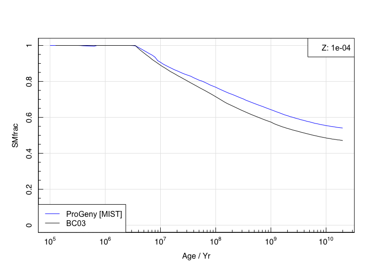

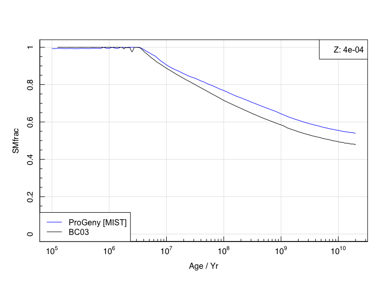

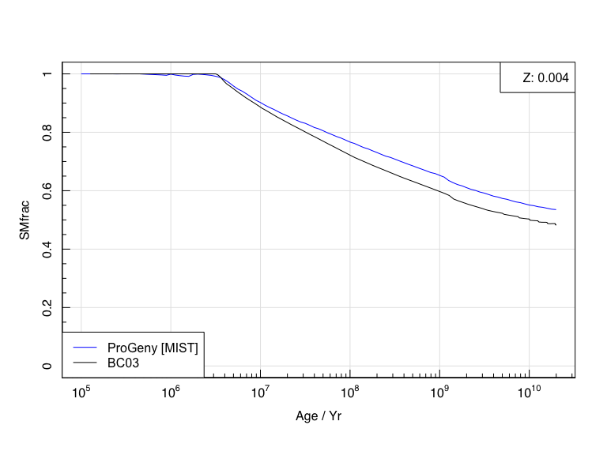

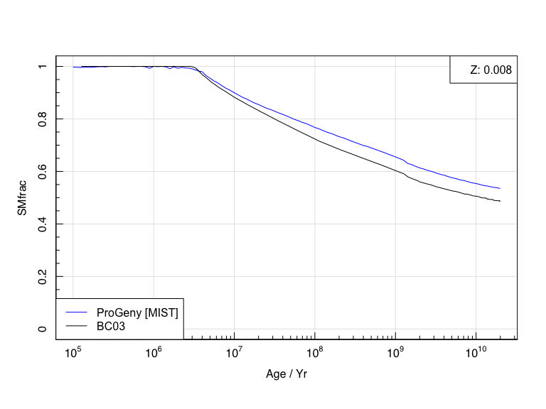

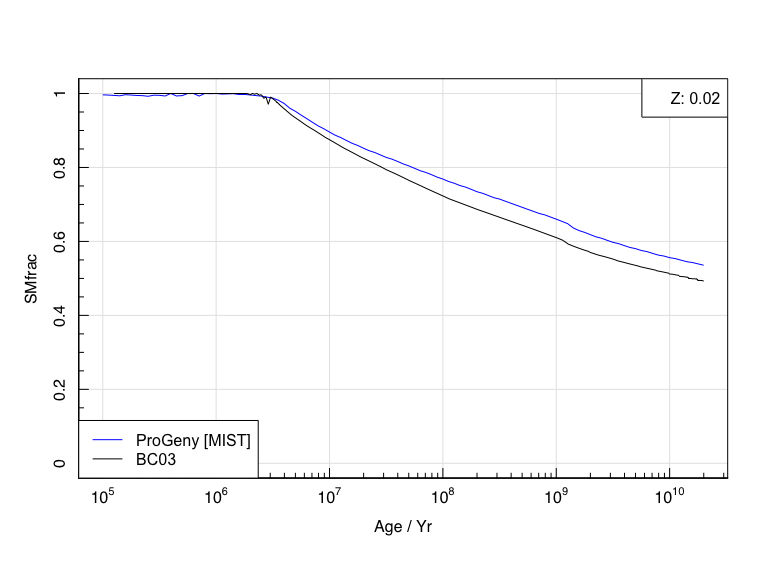

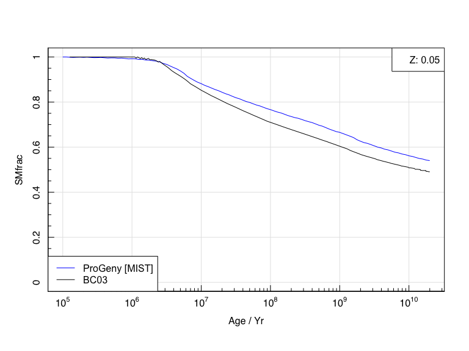

```r
for(Z in BC03lr$Z){
  magplot(PG_Ch_PHOENIX$Age, PG_Ch_PHOENIX$Zevo[[min(which(PG_Ch_PHOENIX$Z >= Z))]]$SMstar, type='l', ylim=c(0,1),
          log='x', xlab='Age / Yr', ylab = 'SMfrac', col='blue')
  lines(BC03lr$Age, BC03lr$Zevo[[min(which(BC03lr$Z >= Z))]]$SMstar, col='black')
  legend('bottomleft', legend=c('ProGeny [MIST]', 'BC03'), col=c('blue', 'black'), lty=1)
  legend('topright', legend=paste('Z:',Z))
}
```

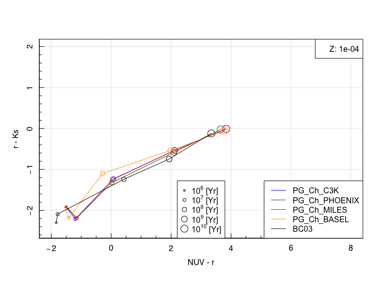

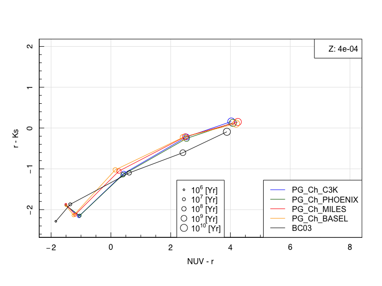

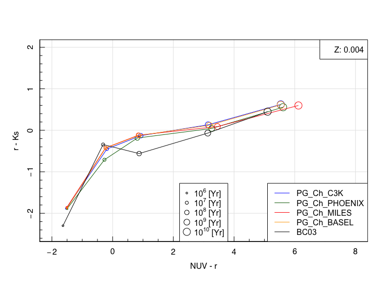

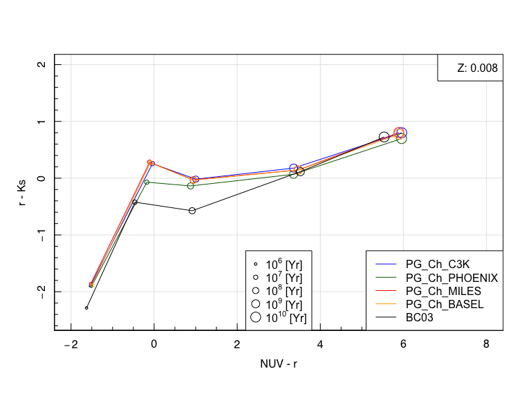

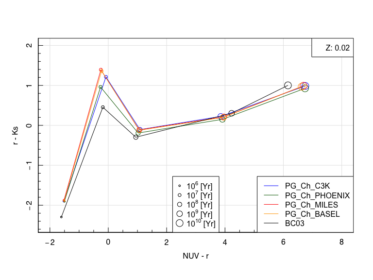

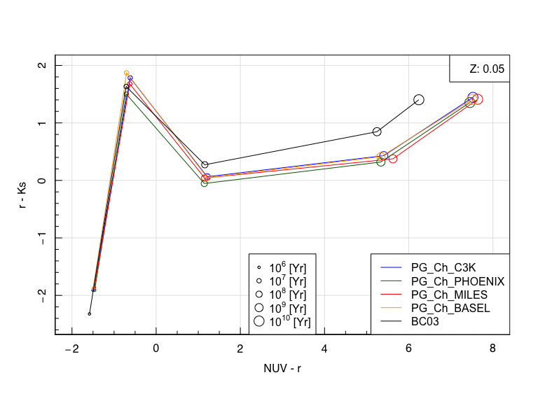

```r
NUV_filt = getfilt('NUV')
r_filt = getfilt('r_VST')
Ks_filt = getfilt('Ks_VISTA')

for(Z in BC03lr$Z){
  mag_NUV_r_C3K = {}
  mag_r_Ks_C3K = {}
  mag_NUV_r_PHOENIX = {}
  mag_r_Ks_PHOENIX = {}
  mag_NUV_r_MILES = {}
  mag_r_Ks_MILES = {}
  mag_NUV_r_BASEL = {}
  mag_r_Ks_BASEL = {}
  mag_NUV_r_BC03 = {}
  mag_r_Ks_BC03 = {}

  for(logAge in 6:10){
    temp_C3K = specReBin(PG_Ch_C3K$Wave, PG_Ch_C3K$Zspec[[min(which(PG_Ch_C3K$Z >= Z))]][min(which(PG_Ch_C3K$Age >= 10^logAge)),], BC03lr$Wave)
    temp_PHOENIX = specReBin(PG_Ch_PHOENIX$Wave, PG_Ch_PHOENIX$Zspec[[min(which(PG_Ch_PHOENIX$Z >= Z))]][min(which(PG_Ch_PHOENIX$Age >= 10^logAge)),], BC03lr$Wave)
    temp_MILES = specReBin(PG_Ch_MILES$Wave, PG_Ch_MILES$Zspec[[min(which(PG_Ch_MILES$Z >= Z))]][min(which(PG_Ch_MILES$Age >= 10^logAge)),], BC03lr$Wave)
    temp_BASEL = specReBin(PG_Ch_BASEL$Wave, PG_Ch_BASEL$Zspec[[min(which(PG_Ch_BASEL$Z >= Z))]][min(which(PG_Ch_BASEL$Age >= 10^logAge)),], BC03lr$Wave)
    temp_BC03 = cbind(BC03lr$Wave, BC03lr$Zspec[[min(which(BC03lr$Z >= Z))]][min(which(BC03lr$Age >= 10^logAge)),])

    mag_NUV_r_C3K = c(mag_NUV_r_C3K, magABcalc(temp_C3K, filter=NUV_filt) - magABcalc(temp_C3K, filter=r_filt))
    mag_r_Ks_C3K = c(mag_r_Ks_C3K, magABcalc(temp_C3K, filter=r_filt) - magABcalc(temp_C3K, filter=Ks_filt))
    mag_NUV_r_PHOENIX = c(mag_NUV_r_PHOENIX, magABcalc(temp_PHOENIX, filter=NUV_filt) - magABcalc(temp_PHOENIX, filter=r_filt))
    mag_r_Ks_PHOENIX = c(mag_r_Ks_PHOENIX, magABcalc(temp_PHOENIX, filter=r_filt) - magABcalc(temp_PHOENIX, filter=Ks_filt))
    mag_NUV_r_MILES = c(mag_NUV_r_MILES, magABcalc(temp_MILES, filter=NUV_filt) - magABcalc(temp_MILES, filter=r_filt))
    mag_r_Ks_MILES = c(mag_r_Ks_MILES, magABcalc(temp_MILES, filter=r_filt) - magABcalc(temp_MILES, filter=Ks_filt))
    mag_NUV_r_BASEL = c(mag_NUV_r_BASEL, magABcalc(temp_BASEL, filter=NUV_filt) - magABcalc(temp_BASEL, filter=r_filt))
    mag_r_Ks_BASEL = c(mag_r_Ks_BASEL, magABcalc(temp_BASEL, filter=r_filt) - magABcalc(temp_BASEL, filter=Ks_filt))
    mag_NUV_r_BC03 = c(mag_NUV_r_BC03, magABcalc(temp_BC03, filter=NUV_filt) - magABcalc(temp_BC03, filter=r_filt))
    mag_r_Ks_BC03 = c(mag_r_Ks_BC03, magABcalc(temp_BC03, filter=r_filt) - magABcalc(temp_BC03, filter=Ks_filt))
  }

  magplot(mag_NUV_r_C3K, mag_r_Ks_C3K, type='l', col='blue', xlim=c(-2,8), ylim=c(-2.5,2), xlab='NUV - r', ylab='r - Ks')
  points(mag_NUV_r_C3K, mag_r_Ks_C3K, cex=seq(0.5,2,len=5), col='blue')
  lines(mag_NUV_r_PHOENIX, mag_r_Ks_PHOENIX, col='darkgreen')
  points(mag_NUV_r_PHOENIX, mag_r_Ks_PHOENIX, cex=seq(0.5,2,len=5), col='darkgreen')
  lines(mag_NUV_r_MILES, mag_r_Ks_MILES, col='red')
  points(mag_NUV_r_MILES, mag_r_Ks_MILES, cex=seq(0.5,2,len=5), col='red')
  lines(mag_NUV_r_BASEL, mag_r_Ks_BASEL, col='orange')
  points(mag_NUV_r_BASEL, mag_r_Ks_BASEL, cex=seq(0.5,2,len=5), col='orange')
  lines(mag_NUV_r_BC03, mag_r_Ks_BC03, col='black')
  points(mag_NUV_r_BC03, mag_r_Ks_BC03, cex=seq(0.5,2,len=5), col='black')
  legend('bottomright', legend=c('PG_Ch_C3K', 'PG_Ch_PHOENIX', 'PG_Ch_MILES', 'PG_Ch_BASEL', 'BC03'), col=c('blue', 'darkgreen', 'red', 'orange', 'black'), lty=1)
  legend('topright', legend=paste('Z:',Z))
  legend('bottom', legend=c(expression(10^6*' [Yr]'), expression(10^7*' [Yr]'), expression(10^8*' [Yr]'), expression(10^9*' [Yr]'), expression(10^10*' [Yr]')), pt.cex=seq(0.5,2,len=5), pch=1)
}
```